# STAT 420: Project 1

# Part 3

**(a)**

```r
set.seed(42)
n = 25

x0 = rep(1, n)
x1 = runif(n, 0, 10)
x2 = runif(n, 0, 10)
x3 = runif(n, 0, 10)
x4 = runif(n, 0, 10)
X = cbind(x0, x1, x2, x3, x4)
C = solve(t(X) %*% X)
y = rep(0, n)
ex_4_data = data.frame(y, x1, x2, x3, x4)

diag(C)
```

```
##          x0          x1          x2          x3          x4
## 0.744784994 0.004573055 0.005091328 0.005898213 0.005058979
```

```r
ex_4_data[10,]
```

```
##    y       x1         x2       x3       x4
## 10 0 7.050648 0.03948339 5.144129 7.758234
```

**(b)**

```r
beta_hat_1 = numeric(1500)
beta_2_pval = numeric(1500)
beta_3_pval = numeric(1500)
```

**(c)**

```r
for (i in 1:1500) {
  ex_4_data[, 1] = 2 + 3*x1 + 4*x2 + 0*x3 + 1*x4 + rnorm(25, 0, 4)
  y = ex_4_data[,1]
  model = lm(y ~ x1 + x2 + x3 + x4)
  beta_hat_1[i] = summary(model)$coef[2]
  beta_2_pval[i] = summary(model)$coef[3,4]
  beta_3_pval[i] = summary(model)$coef[4,4]
}
```

**(d)**

```r
true_var = (16*C)[2,2]
true_var
```

```
## [1] 0.07316889
```

True distribution of $\hat\beta_1$ is mean: 3 and variance: 0.0731689.  
**(e)**

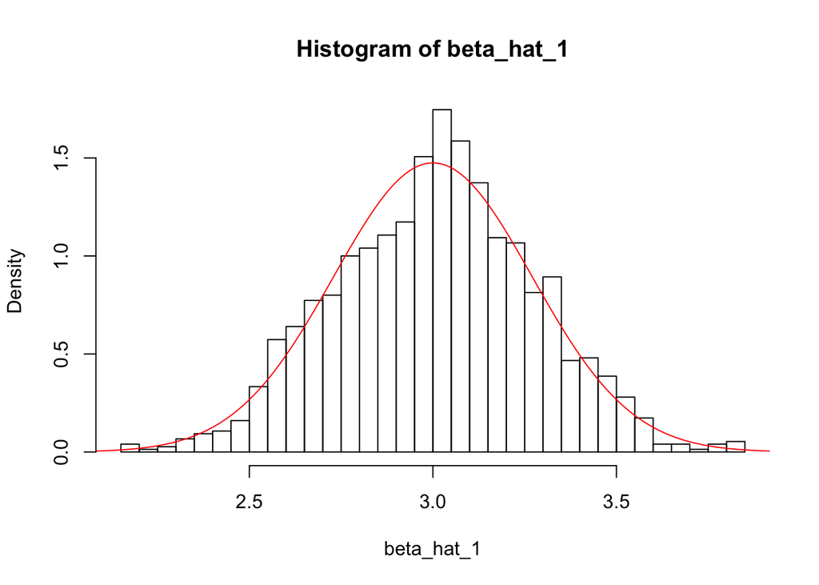

```r
beta_hat_1_mean = mean(beta_hat_1)
beta_hat_1_var = var(beta_hat_1)

hist(beta_hat_1, prob = TRUE, breaks = 50)
x = seq(0, 6, length=1000)
y = dnorm(x, 3, sqrt(true_var))
lines(x,y, col = "red")
```

```r
beta_hat_1_mean
```

```
## [1] 3.006391
```

```r
beta_hat_1_var
```

```
## [1] 0.07303341
```

The mean and variance of `beta_hat_1` are close to 3 and 0.0731689.  
The curve also matches the histogram.  
**(f)**

```r
prop = mean(beta_3_pval < 0.05)
prop
```

```
## [1] 0.04666667
```

The proportion is 0.0466667, which means most of the tests fail to reject the null hypothesis ($H_0: \beta_3 = 0$) with $\alpha = 0.05$.  
It is expected because the true value of $\beta_3$ is 0.  
**(g)**

```r
mean(beta_2_pval < 0.05)
```

```
## [1] 1
```

The proportion is 1, which means all of the tests reject the null hypothesis ($H_0: \beta_2 = 0$) with $\alpha = 0.05$.  
It is expected because the true value of $\beta_2$ is 4, which is far from 0.